# Causality and Structural Equation Modelling

Kirsty Kitto

May 26 2018

How many times have you heard the slogan: “correlation does not imply causation”?

This saying is really just saying that just because two events always come one after the other, it doesn’t mean that the first event *caused* the second. (That is, the rooster crowing does not *cause* the sun to rise!)

This is a real problem, in particular for AI. If we tell a robot both:

1. If the grass is wet, then it rained ($GW\rightarrow R$); and
2. If we break this bottle, the grass will get wet ($BB\rightarrow GW$).

Then it may well conclude that if it breaks the bottle then it will have rained! ($BB\rightarrow R$). This is not something that we want a robot to conclude, and even less something we want it to do!

Well there is a bit of a revolution that has been occuring in the last 30 years, which mainly came out of AI, due to the work of Judea Pearl. He showed that sometimes, when we have information about how correlations change in time, we *can* start to infer causal information from our data.

This is a very important advance! Most questions in the health, social and behavioural sciences are not associational but *causal*. People want to know things like:

- Did a cut in funding to public housing cause an increase Sydney house prices?
- Does obesity cause diabetes?
- Will an increase in public transport services on Friday nights lead to reduced road deaths?
- Will user satisfation increase if this new feature is added?
- Is a company guilty of discrimination in its hiring practices?
- What was the cause of death of an individual?

These questions are causal because they cannot be answered from the data alone, or of the distributions that govern that data. Instead, they require some knowledge of the data-generating process, and in particular, of *how that process changes in time*.

Thus, causal analysis aims to infer not only beliefs or probabilities under static conditions, but also to understand how they will change. For example, changes induced by treatments or external interventions in a system.

This type of problem requires extensions to the standard language of statistics, and this extra mathematical apparatus is relatively new (having been largely developed by Judea Pearl one of the champions of Bayesian networks in the 1980’s). This means that these technical extensions are not widely known about in the fields that could put them to best use. Here, we will just start to explore these issues in very shallow detail (hopefully enough to whet your interest!) Make sure you follow up the links in this workbook for extra information if you would like to pursue this line of thinking for Assessment 3.

Right, what if we have a thing that works by takes a variable X, and does some stuff to it in the following sequence.

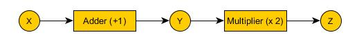

We could represent this process with the two equations:

$Y = X + 1$  
$Z = 2Y$

Are they equivalent? Actually, Pearl argues no. He says that if you rearrange the equations like this:

$X = Y – 1$  
$Y = Z/2$

which is a fine thing to do according mathematics, then you actually get something that goes backwards

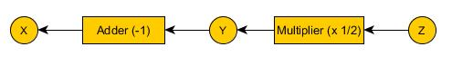

That means that if you do something that changes $Y$ in both situations, then while the equations give you the same thing, the diagrams would give you something different! Pearl claims that the diagrams are more useful, as they help us to answer questions like the ones I was asking above.

Pearl introduces a new operator $do()$ to standard probability theory. This operator allows us to distinguish between an association, and actually *doing* something. If you want to see some details about how this operator works then you should go and check out this page for a brief introduction: https://formalisedthinking.wordpress.com/2010/08/26/a-causal-calculus-processing-causal-information/ (this is a very nice sequence of posts on the topic!)

Let’s think how this works via an example Pearl used about smoking. Basically, let’s explore this statement: *Smoking causes lung cancer via the intermediary of building up tar deposits in the lungs. There is also a genetic feature that both increases the chance of developing cancer and increases the chance of a person taking up smoking.*

Here is a causal graph illustrating that statement:

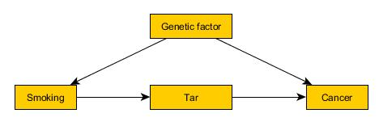

The problem is then to determine the *strength* of the connections between the nodes: the probability of cancer given $do(smoking)$. See this page for a more detailed overview of how this is done formally: https://formalisedthinking.wordpress.com/2010/09/02/reasoning-with-causality-an-example/

We are not going to work through this, instead we are going to learn how to use the apparatus of Structural Equation Modelling (SEM) to pull out probabilities like these. If you want to find out more then you should definitely work through some of the resources below! (It will be challenging but rewarding!)

### More information

- A really nice place to start is this sequence of blog posts by someone exploring Pearl’s classic book on this subject: https://formalisedthinking.wordpress.com/2010/08/20/pearls-formalisation-of-causality-sequence-index/
- Week 5, parts h-j (on model building) of the Statistical Thinking for Data Science MOOC: https://courses.edx.org/courses/course-v1:ColumbiaX+DS101X+1T2016/course/
- Pearl, J. (2009). Causal inference in statistics: An overview. Statistics surveys, 3, 96-146. http://ftp.cs.ucla.edu/pub/stat_ser/r350.pdf (A really well written and extensive paper by the father of this approach. Its good reading and will provide you with much of what you need to know to get started in this area.)
- A video tutorial by Pearl on the subject: https://www.microsoft.com/en-us/research/video/tutorial-session-b-causes-and-counterfactuals-concepts-principles-and-tools/?from=http%3A%2F%2Fresearch.microsoft.com%2Fapps%2Fvideo%2Fdefault.aspx%3Fid%3D206977
- From correlation to causation: https://onlinecourses.science.psu.edu/stat504/node/185 (a nice set of resources that you could chase up on the topic)
- The DAGitty primer, http://dagitty.net/primer/ and the tool itself: http://www.dagitty.net/ (which is useful if you want to draw DAGs)

## Structural Equation Models (SEM)

The smoking graph above is essentially a Directed Acyclic Graph (DAG). The challenge is usually to come up with one. Normally this involves expert domain knowledge, and the repeated testing of a hypothesis against a dataset that grows as new factors are incorporated into a model (a process often called *model building*.) Normally you cannot just use brute force evaluation in a real world scenario: there are just too many variables and pulling everything out is just too computationally intensive.

An example of the way in which a group gradually builds up their DAG is given by this paper for an ecological scenario:

- Grace, J. B., Anderson, T. M., Olff, H., & Scheiner, S. M. (2010). [On the specification of structural equation models for ecological systems](http://articles.lib.uts.edu.au/search?record_id=wj10.1890%2F09-0464.1&page=1). Ecological Monographs, 80(1), 67-87.

Once you have a DAG, you can start to do things like construct models about how the latent variables interrelate. For example, consider the PoliticalDemocracy dataset.

```r
library(lavaan)
?PoliticalDemocracy
```

In essence, this dataset contains various measures of political democracy and industrialization in developing countries… (look up the helpfile for it to find out who collected it and when!)

Lets look at the data:

```r
str(PoliticalDemocracy)
```

```
## 'data.frame':    75 obs. of  11 variables:
##  $ y1: num  2.5 1.25 7.5 8.9 10 7.5 7.5 7.5 2.5 10 ...
##  $ y2: num  0 0 8.8 8.8 3.33 ...
##  $ y3: num  3.33 3.33 10 10 10 ...
##  $ y4: num  0 0 9.2 9.2 6.67 ...
##  $ y5: num  1.25 6.25 8.75 8.91 7.5 ...
##  $ y6: num  0 1.1 8.09 8.13 3.33 ...
##  $ y7: num  3.73 6.67 10 10 10 ...
##  $ y8: num  3.333 0.737 8.212 4.615 6.667 ...
##  $ x1: num  4.44 5.38 5.96 6.29 5.86 ...
##  $ x2: num  3.64 5.06 6.26 7.57 6.82 ...
##  $ x3: num  2.56 3.57 5.22 6.27 4.57 ...
```

Ok, from the helpfile (`?PoliticalDemocracy`) we have this explanation of these variables

| Variable | Description |
| --- | --- |
| y1 | Expert ratings of the freedom of the press in 1960 |
| y2 | The freedom of political opposition in 1960 |
| y3 | The fairness of elections in 1960 |
| y4 | The effectiveness of the elected legislature in 1960 |
| y5 | Expert ratings of the freedom of the press in 1965 |
| y6 | The freedom of political opposition in 1965 |
| y7 | The fairness of elections in 1965 |
| y8 | The effectiveness of the elected legislature in 1965 |
| x1 | The gross national product (GNP) per capita in 1960 |
| x2 | The inanimate energy consumption per capita in 1960 |
| x3 | The percentage of the labor force in industry in 1960 |

Bollen (the guy who collected the data) proposed a set of *Latent Variables* that would help to link behaviour of the underlying observables.

### Latent Variables

Bollen proposed these ones:

- ind60: the degree of industrialization in 1960
- dem60: political democracy in 1960
- dem65: political democracy in 1965

There is reason to believe (from prior research, you can download one of the papers here: Bollen, K. A. (1980). [Issues in the comparative measurement of political democracy](http://articles.lib.uts.edu.au/#search?record_id=jstor_archive_12095172&page=1). American Sociological Review, 370-390.) that the following graphical model gives a good representation of it:

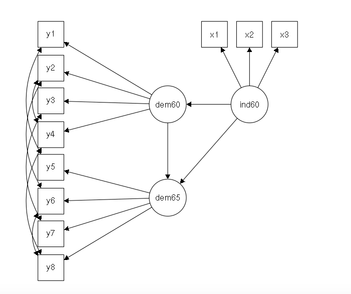

Figure 1: A proposed structural model of how the variables in the PoliticalDemocracy dataset influence one another.

Interesting… can you provide some sort of an interpretation of what is going on here?

# Structural Equation Modelling (SEM)

But to test this proposed model, we need to see if the variables can explain the data.

We do this by defining a model that represents this graphical image in R:

```r
model <- '
  # latent variable model
    ind60 =~ x1 + x2 + x3
    dem60 =~ y1 + y2 + y3 + y4
    dem65 =~ y5 + y6 + y7 + y8
  # regressions
    dem60 ~ ind60
    dem65 ~ ind60 + dem60
  # residual correlations (covariances)
    y1 ~~ y5
    y2 ~~ y4 + y6
    y3 ~~ y7
    y4 ~~ y8
    y6 ~~ y8
'
```

Now we can try fitting the data

```r
fit <- sem(model, data=PoliticalDemocracy)
summary(fit, standardized=TRUE)
```

```
## lavaan (0.5-23.1097) converged normally after  68 iterations
##
##   Number of observations                            75
##
##   Estimator                                         ML
##   Minimum Function Test Statistic               38.125
##   Degrees of freedom                                35
##   P-value (Chi-square)                           0.329
##
## Parameter Estimates:
##
##   Information                                 Expected
##   Standard Errors                             Standard
##
## Latent Variables:
##                    Estimate  Std.Err  z-value  P(>|z|)   Std.lv  Std.all
##   ind60 =~
##     x1                1.000                               0.670    0.920
##     x2                2.180    0.139   15.742    0.000    1.460    0.973
##     x3                1.819    0.152   11.967    0.000    1.218    0.872
##   dem60 =~
##     y1                1.000                               2.223    0.850
##     y2                1.257    0.182    6.889    0.000    2.794    0.717
##     y3                1.058    0.151    6.987    0.000    2.351    0.722
##     y4                1.265    0.145    8.722    0.000    2.812    0.846
##   dem65 =~
##     y5                1.000                               2.103    0.808
##     y6                1.186    0.169    7.024    0.000    2.493    0.746
##     y7                1.280    0.160    8.002    0.000    2.691    0.824
##     y8                1.266    0.158    8.007    0.000    2.662    0.828
##
## Regressions:
##                    Estimate  Std.Err  z-value  P(>|z|)   Std.lv  Std.all
##   dem60 ~
##     ind60             1.483    0.399    3.715    0.000    0.447    0.447
##   dem65 ~
##     ind60             0.572    0.221    2.586    0.010    0.182    0.182
##     dem60             0.837    0.098    8.514    0.000    0.885    0.885
##
## Covariances:
```

[output cut: 14 more lines]

```
##                    Estimate  Std.Err  z-value  P(>|z|)   Std.lv  Std.all
##    .x1                0.082    0.019    4.184    0.000    0.082    0.154
##    .x2                0.120    0.070    1.718    0.086    0.120    0.053
##    .x3                0.467    0.090    5.177    0.000    0.467    0.239
##    .y1                1.891    0.444    4.256    0.000    1.891    0.277
##    .y2                7.373    1.374    5.366    0.000    7.373    0.486
##    .y3                5.067    0.952    5.324    0.000    5.067    0.478
##    .y4                3.148    0.739    4.261    0.000    3.148    0.285
##    .y5                2.351    0.480    4.895    0.000    2.351    0.347
##    .y6                4.954    0.914    5.419    0.000    4.954    0.443
##    .y7                3.431    0.713    4.814    0.000    3.431    0.322
##    .y8                3.254    0.695    4.685    0.000    3.254    0.315
##     ind60             0.448    0.087    5.173    0.000    1.000    1.000
##    .dem60             3.956    0.921    4.295    0.000    0.800    0.800
##    .dem65             0.172    0.215    0.803    0.422    0.039    0.039
```

Ok. That is what Kirsty just did… Make sure that you really explore this information, and try to work out what it means. This post might help: https://stats.stackexchange.com/questions/140909/how-do-i-interpret-lavaan-output

The semPaths function (from semPlot) lets us visualise the weightings that our model has generated. This can help with the interpretation…

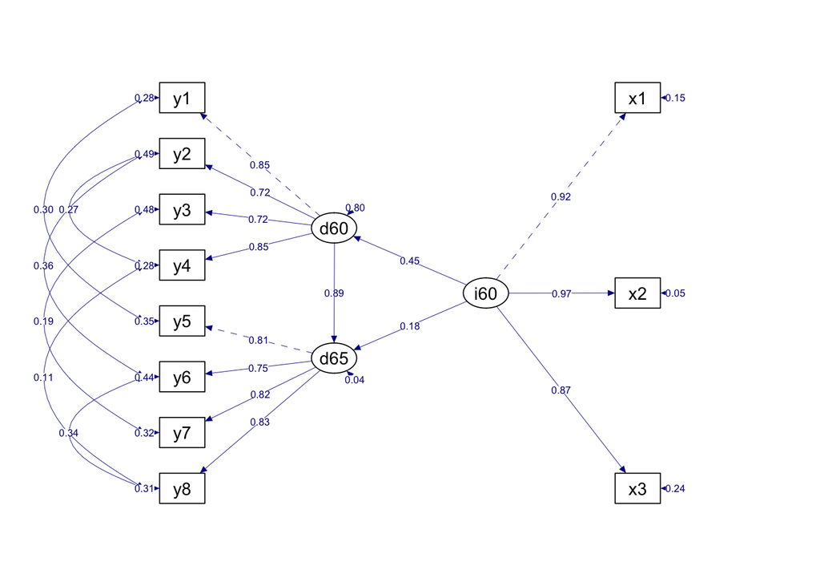

```r
library(semPlot)
semPaths(fit, style="lisrel",
        whatLabels = "std", edge.label.cex = .6, label.prop=0.9,
        rotation = 4, equalizeManifests = FALSE, optimizeLatRes = TRUE,
        node.width = 1.5, edge.width = 0.5, shapeMan = "rectangle",
        shapeLat = "ellipse", shapeInt = "triangle",
        sizeMan = 4, sizeInt = 2, sizeLat = 4,
        curve=2, unCol = "#070b8c")
```

Make sure that you check out the help pages (i.e. run ?semPaths) to find out what this command is doing.

It is possible to obtain confidence intervals for the estimated coefficients, which will tell us alittle bit more about how well the model is working…

```r
parameterEstimates(fit, ci = TRUE, level = 0.95)
```

```
##      lhs op   rhs   est    se      z pvalue ci.lower ci.upper
## 1  ind60 =~    x1 1.000 0.000     NA     NA    1.000    1.000
## 2  ind60 =~    x2 2.180 0.139 15.742  0.000    1.909    2.452
## 3  ind60 =~    x3 1.819 0.152 11.967  0.000    1.521    2.116
## 4  dem60 =~    y1 1.000 0.000     NA     NA    1.000    1.000
## 5  dem60 =~    y2 1.257 0.182  6.889  0.000    0.899    1.614
## 6  dem60 =~    y3 1.058 0.151  6.987  0.000    0.761    1.354
## 7  dem60 =~    y4 1.265 0.145  8.722  0.000    0.981    1.549
## 8  dem65 =~    y5 1.000 0.000     NA     NA    1.000    1.000
## 9  dem65 =~    y6 1.186 0.169  7.024  0.000    0.855    1.517
## 10 dem65 =~    y7 1.280 0.160  8.002  0.000    0.966    1.593
## 11 dem65 =~    y8 1.266 0.158  8.007  0.000    0.956    1.576
## 12 dem60  ~ ind60 1.483 0.399  3.715  0.000    0.701    2.265
## 13 dem65  ~ ind60 0.572 0.221  2.586  0.010    0.139    1.006
## 14 dem65  ~ dem60 0.837 0.098  8.514  0.000    0.645    1.030
```

[output cut: 20 more lines]

We can also obtain goodness of fit indicators of the model

```r
fitMeasures(fit, c("chisq", "rmsea", "srmr", "gfi", "ecvi"))
```

```
##  chisq  rmsea   srmr    gfi   ecvi
## 38.125  0.035  0.044  0.923  1.335
```

And work out its reliability using a function from the semTools package

```r
library(semTools)
reliability(fit)
```

```
##            ind60     dem60     dem65     total
## alpha  0.9023348 0.8587945 0.8827394 0.9149416
## omega  0.9437375 0.8375193 0.8556193 0.9134989
## omega2 0.9437375 0.8375193 0.8556193 0.9134989
## omega3 0.9436896 0.8411801 0.8575540 0.9192058
## avevar 0.8588015 0.5996707 0.6408647 0.6320779
```

Try running ?reliability to find out more about what this output means.

For now you could:

1. Try some different models
2. Try plotting some of the outputs above to see if you can visualise them more intuitively

SO - if you got here and still have time, you should go off and do a bit more exploring…

### More information

- The Lavaan tutorial is a great place to start if you want to find out more about SEM: http://lavaan.ugent.be/tutorial/ It is very clearly laid out and also has a section on Confirmatory Factor Analysis (CFA) which is another thing you might find yourself finding that you want to do.
- This is also a more detailed blog on SEM: http://pacha.hk/2017-01-15_sem_r_part_2.html
- A good set of slides on lavaan: https://personality-project.org/r/tutorials/summerschool.14/rosseel_sem_intro.pdf
- A couple of MDSI students also tried to build a SEM, see: https://16-4256.ca.uts.edu.au/exploring-climate-change-sceptics-and-attitudes-using-sem/ and https://16-7050.ca.uts.edu.au/searching-for-hierarchical-individualists-in-the-2008-eurobarometer-survey/